# Replication of Study 1 by Sharif & Oppenheimer (2016, Psychological Science)

Benjamin E. deMayo (bdemayo@stanford.edu)

December 15, 2017

## Introduction

This is a replication of Sharif & Oppenheimer, 2016, published in Psychological Science. The authors were interested in the role of relative encoding in memory-based judgments.The general hypothesis is that people encode past experiences in an inherently relative way before being exposed to the entire distribution from which the experience was drawn, and that during a later appraisal of the event, people fail to properly adjust their initial encoding given exposure to a greater proportion of the distribution. In Study 1, the authors investigated this phenomenon with regards to people’s judgments of music quality. Participants listened either to two very bad singers (“T1-top condition”) or two very good singers (“T1-bottom condition”) before hearing an average singer, who would be designated as the target singer for each trial. They then completed a challenging distractor task, followed by hearing two more average singers at the same level as the first average singer. Participants were then asked to eliminate one singer from the competition and choose one as the winner. The authors found that people were more likely to choose the target singer as the loser of the competition in the T1-bottom condition, obstensibly because they initially encoded that singer negatively compared to the first two good singers presented. Similarly, authors found that in the T1-top condition, the target singer was more likely to be chosen as the winner. These two results are the ones that are being tested in this replication.

## Methods

### Power Analysis

Effect size reported in the paper for the main chi-squared goodness of fit test was small, *w* = .212, df = 2. The chi-square goodness of fit test examined whether the target singer was chosen as the winner (in the top condition) or as the loser (in the bottom condition) with greater frequency than would be predicted by chance. Sample sizes for 80%, 90%, and 95% a priori power for this statistical test were large: 215, 282 and 344, respectively. Budget limitations make these sample sizes non-feasible. The replication will use the original sample size excluding exclusions, n = 90.

### Planned Sample

Planned sample is the original publication sample size after removing participants who failed the manipulation check, *n* = 90.

### Materials

Survey materials from the original publication were made available by M. Sharif and D. Oppenheimer on Open Science Framework, allowing me to replicate their survey exactly on Qualtrics, with some small modifications. A description of the video stimuli from the original paper is provided below:

> Stimuli. A series of clips of singers was downloaded from YouTube. Audio-only files of the clips were pretested on Amazon Mechanical Turk by 71 participants. Ten to 11 participants evaluated each clip by rating how good they thought the singer was on a 7-point Likert scale (1 = not good at all, 7 = very good). We selected two clips that were perceived to be very bad (M = 1.50, SD = 0.85; M = 1.70, SD = 0.95), three clips that were perceived to be average (M = 3.90, SD = 0.87; M = 3.90, SD = 1.00; M = 3.70, SD = 1.16), and two clips that were perceived to be very good (M = 6.20, SD = 0.63; M = 6.00, SD = 1.16).

Participants in the original paper and in the replication are recruited on Amazon Mechanical Turk.

### Procedure

The following procedure was adhered to precisely:

> Participants were asked to imagine that they were judges at a singing competition and would listen to competitors in two auditions, the first in Los Angeles and the second in New York City. They were randomly assigned to one of two conditions. Half of the participants first listened to the two very bad singers and then to one average singer (the target singer). Because the target singer was at the top of the Time 1 distribution, we refer to this condition as the T1-top condition. The other half of the participants first listened to the two very good singers and then to one average singer (the target singer). Because the target singer was at the bottom of the Time 1 distribution, we refer to this condition as the T1-bottom condition. After listening to the three clips, participants were told to imagine that they were traveling to the next audition and needed to tune their recording equipment. They then engaged in a distractor task designed to clear auditory memory. On each trial, they listened to a series of four sounds sequentially and were then asked a question about the sounds. They completed five trials, with a different question asked on each trial (e.g., which sound played the longest, which sound had the lowest pitch). After this distractor task, participants were told that they had arrived in New York City. All of the participants, regardless of condition, then listened to two average, nontarget, singers (roughly equal in quality to the target singer according to the pretest). Which average singer was the target singer and which average singers were the nontarget singers were counterbalanced across participants. At the end of the second set of auditions, participants chose one singer as the winner of the competition. They also selected one contestant to eliminate, in a procedure akin to the approach on American Idol (Blankens, 2002-2016).

The survey will be administered through Qualtrics on Amazon Mechanical Turk.

### Analysis Plan

Original data will be consolidated (using tidyr function gather) to show each participant’s condition, counterbalance order, which singers they chose as the loser and winner, and a column with binary values indicating whether the target was chosen as empirically predicted. Columns indicating participants’ familiarity with each of the songs will also included for the purpose of exploratory post-hoc analyses.

Participants will also be excluded from the confirmatory analysis if they eliminate one of the “good” singers in the T1-bottom condition or choose one of the “bad” singers as the winner in the T1-top condition – this serves as the manipulation check to make sure participants are actually attending to the quality of the singers in the videos.

**Key analysis of interest** A chi-square goodness-of-fit test, df will be used to test whether participants’ selection of the target singers as winners and losers in the T1-top and T1-bottom condition, respectively differs significantly from chance.

### Differences from Original Study

The sample size is slightly smaller than in the original publication due to budget constraints, making the a priori statistical power slightly below 50%. Verification of stimuli validity will not be re-performed in the replication attempt. The procedure attempts to replicate the original survey exactly, except for inclusion of institution-specific IRB text and the exclusion of certain demographic questions that were not analyzed in the published paper.

#### Actual Sample

Sample size, demographics, data exclusions based on rules spelled out in analysis plan Ninety participants were recruited on Amazon Mechanical Turk. Demographic information was not collected, since no demographic data were presented in the original publication. Participants were excluded form the confirmatory analyses if they chose a non-average singer as the loser in the “bottom” condition, or chose an non-average singer as the winner in the “top” condition.

#### Differences from pre-data collection methods plan

Data were collected exactly as specified in the pre-data collection methods plan.

## Results

### Data preparation

Data preparation following the analysis plan.

### Confirmatory analysis

```r
head(d_without_exclusions)
```

```
## # A tibble: 6 x 14
##          ResponseId condition counterbalance winner eliminate
##               <chr>     <chr>          <chr>  <dbl>     <dbl>
## 1 R_3dETjy295ym4ZT3 t1_bottom    t1_bottom_a      2         3
## 2 R_6XTv9oyc3NqRhLz t1_bottom    t1_bottom_a      2         3
## 3 R_r2BTP0X4cU5Rzhf t1_bottom    t1_bottom_a      1         3
## 4 R_Aill4hN6FBmu1Cp t1_bottom    t1_bottom_a      1         4
## 5 R_1MPYvc7Kjw6NMes t1_bottom    t1_bottom_a      2         5
## 6 R_2B8PqPH9BPLgzSS t1_bottom    t1_bottom_a      1         3
## # ... with 9 more variables: familiarity_1 <dbl>, familiarity_2 <dbl>,
## #   familiarity_3 <dbl>, familiarity_4 <dbl>, familiarity_5 <dbl>,
## #   exclude <dbl>, target_chosen <dbl>, fourth_chosen <dbl>,
## #   fifth_chosen <dbl>
```

```r
##Chi-square goodness-of-fit test, verifying whether the distribution differs significantly from chance
tallies <- c(sum(d_without_exclusions$target_chosen), sum(d_without_exclusions$fourth_chosen), sum(d_without_exclusions$fifth_chosen))
test <- chisq.test(tallies, p = c(1/3, 1/3, 1/3))
test
```

```
##
##  Chi-squared test for given probabilities
##
## data:  tallies
## X-squared = 12.026, df = 2, p-value = 0.002447
```

```r
es <- ES.chisq.gof(tallies, c(1/3, 1/3, 1/3))
es
```

```
##
##      effect size of chi-squared test of goodness of fit
##
##               w = 0.395198
##              p1 = 0.5194805, 0.2467532, 0.2337662
##              p0 = 0.3333333, 0.3333333, 0.3333333
##
## NOTE: Probabilities were same as provided or were rescaled from provided frequencies
## small effect size:  w = 0.1
## medium effect size: w = 0.3
## large effect size:  w = 0.5
```

```r
##Additional goodness of fit test. The test reported in the paper also takes into account variance created by the two non-target average singers, which seems irrelevant to the analysis of interest. This test compares the observed distribution to the expected distribution of 1/3 chance of participants choosing the target singer and 2/3 chance of participants choosing a non-target singer.
adjusted_tallies <-
  c(sum(d_without_exclusions$target_chosen), sum(d_without_exclusions$fourth_chosen) + sum(d_without_exclusions$fifth_chosen))
adjusted_test <- chisq.test(adjusted_tallies, p = c(1/3, 2/3))
adjusted_test
```

```
##
##  Chi-squared test for given probabilities
##
## data:  adjusted_tallies
## X-squared = 12.006, df = 1, p-value = 0.0005302
```

```r
adjusted_es <- ES.chisq.gof(adjusted_tallies, c(1/3, 2/3))
adjusted_es
```

```
##
##      effect size of chi-squared test of goodness of fit
##
##               w = 0.3948778
##              p1 = 0.5194805, 0.4805195
##              p0 = 0.3333333, 0.6666667
##
## NOTE: Probabilities were same as provided or were rescaled from provided frequencies
## small effect size:  w = 0.1
## medium effect size: w = 0.3
## large effect size:  w = 0.5
```

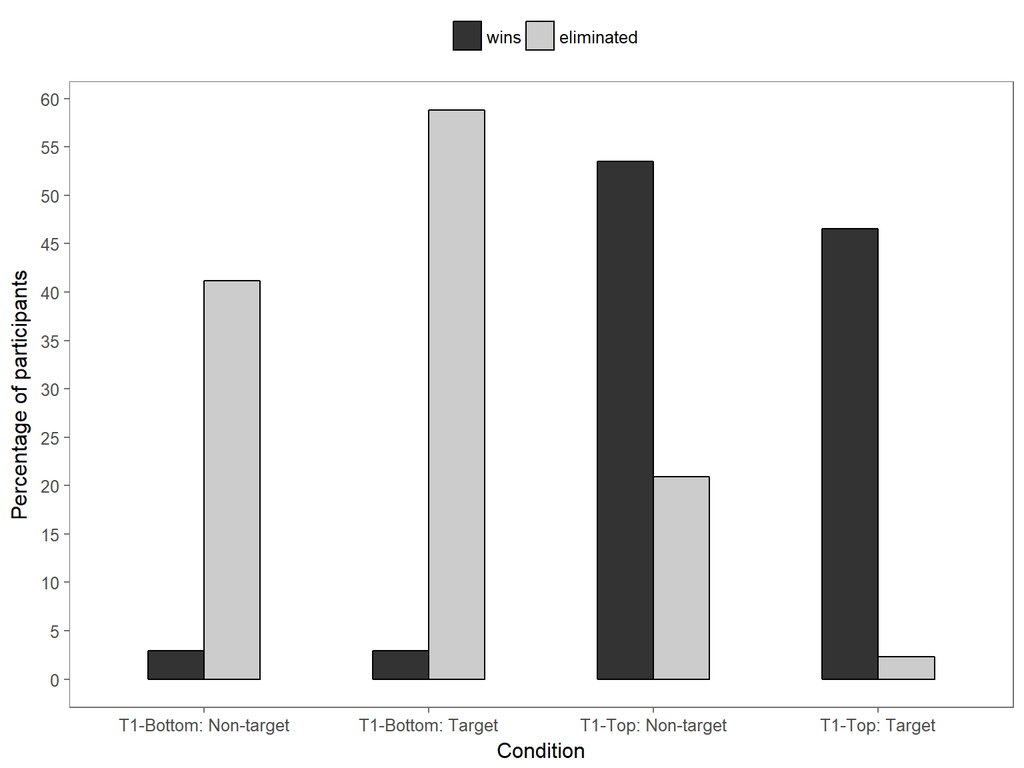

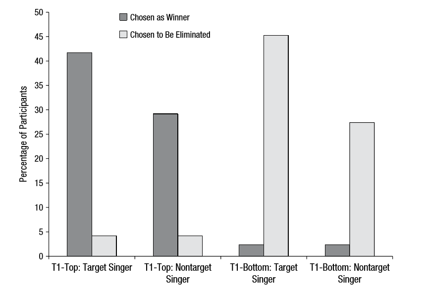

```r
####Reproducing plot in the paper

#first, break down data frame into "top" and "bottom" conditions
bottom <- d_without_exclusions%>%
  filter(condition == "t1_bottom") %>% #filter the bottom condition
  mutate(target_wins = as.numeric(winner == 3), #create columns for bars in plot
         target_eliminated = as.numeric((eliminate ==3)),
         nontarget_wins = as.numeric(winner == 4|winner == 5),
         nontarget_eliminated = as.numeric(eliminate == 4|eliminate == 5)) %>%
  select(-starts_with("familiar"), -starts_with("target_chosen")) %>% #get rid of unnecessary columns
  gather('category', 'value', starts_with('target'), starts_with('nontarget')) %>%
  arrange(ResponseId)

bottom <- bottom%>%
  mutate(target_or_non = sub("\\_.*$", "", bottom$category))

bottom %<>%
  mutate(cond = paste(bottom$condition, bottom$target_or_non, "")) %>%
  mutate(win_or_elim = sub('.*\\_', '', bottom$category))

top <- d_without_exclusions%>%
  filter(condition == "t1_top") %>%
  mutate(target_wins = as.numeric(winner == 3),
         target_eliminated = as.numeric((eliminate ==3)),
         nontarget_wins = as.numeric(winner == 4|winner == 5),
         nontarget_eliminated = as.numeric(eliminate == 4|eliminate == 5)) %>%
  select(-starts_with("familiar"), -starts_with("target_chosen")) %>%
  gather('category', 'value', starts_with('target'), starts_with('nontarget')) %>%
  arrange(ResponseId)

top <- top%>%
  mutate(target_or_non = sub("\\_.*$", "", top$category))

top %<>%
  mutate(cond = paste(top$condition, top$target_or_non, "")) %>%
  mutate(win_or_elim = sub('.*\\_', '', top$category))


plot_data <- bind_rows(bottom,top) %>%
  group_by(cond, win_or_elim) %>%
  summarise(percentage = mean(value)*100)


plot_data$win_or_elim <- factor(plot_data$win_or_elim, levels = c("wins", "eliminated"))



ggplot(plot_data,
      aes(x = factor(cond), y = percentage, fill = win_or_elim)) +
      geom_bar(position = "dodge", stat = "identity", colour = 'black', width = .5) +
      ggthemes::theme_few() +
      scale_fill_grey() +
      theme(legend.position = "top") +
      xlab("Condition") +
      ylab("Percentage of participants") +
      scale_y_continuous(breaks = c(0, 5, 10, 15, 20, 25, 30, 35, 40, 45, 50, 55, 60)) +
      theme(legend.title=element_blank()) +
      scale_x_discrete(labels = c("T1-Bottom: Non-target", "T1-Bottom: Target",
                                  "T1-Top: Non-target", "T1-Top: Target"))
```

## Discussion

### Summary of Replication Attempt

A chi-square goodness-of-fit test was used to examine whether participants differed significantly from chance in their choice of the three average singers. Overall, participants who chose an “average” singer to win in the T1-top condition or to lose in the T1-bottom condition chose the target singer 52% of the time, significantly more than would be predicted by chance (chance = 33.333%), *n* = 77 after exclusions, $\chi^2$ = 12.026, *df* = 2, *p* = 0.002447. This result consititutes a successful replication of the original effect found in Sharif and Oppenheimer’s 2016 publication. Effect size in the replication was considerably larger than in the original publication despite the smaller sample size, *w* = 0.395198 in the replication compared with *w* = 0.212 in the original publication. The authors of the original paper argue that this effect demonstrates evidence that participants’ evaluations of quality are made “relative to the comparison time at the time of evaluation”, and that participants fail to adequately adjust these evaluations once the full distribution of quality has been experienced.

An additional test was performed in the replication which binned both non-target singers into one category, in essence testing the observed distribution of [(percentage who chose the target), (percentage who chose a non-target)] vs. the expected distribution as predicted by chance, [$\frac{1}{3}$, $\frac{2}{3}$]. The analysis confirmed the original finding: $\chi^2$ = 12.006, *df* = 1, *p* < 0.001.

### Commentary

The effect size seen in this replication was much larger than in the original publication. The exact cause for this is unknown - perhaps it is related to the smaller sample size, which may have oversampled people who show the effect demonstrated in the original paper with a larger sample size.

The paradigm seemed to be enjoyable for most participants, although some complained about the unpleasant nature of listening to the high-pitched sounds during the distractor task. The original authors did not specify whether the survey had been designed to prevent participants from advancing in the experiment without having fully watched the video. In retrospect, this edit should have been made in the replication attempt.